# Introduction to multiplex single-cell imaging

## Slide Deck

[interactive chart not shown]

## Multichannel TIFF Data

Here I briefly discuss loading and visualizing raw TIFF data. Typically I focus on data in tabular form post segmentation (not the raw images), but it’s helpful to see what they look like.

### Lung cancer data

The following image is a single ROI from a tissue slice from a patient with non small cell lung carcinoma.Cell and tissue segmentation and cell phenotyping were performed using [inForm](https://www.akoyabio.com/phenoimager/software/inform-tissue-finder/) software. For each image, there are multiple Tiff files output by inForm:

- `lung_component_data.tif`: the multichannel file we are most interested in
- `lung_binary_seg_maps.tif`: 3 channel file with binary segmentation maps
- `lung.tif`: A composite image in RGB format.

```r
# load relevant libraries
library(tidyverse)
library(tiff)
library(EBImage)


# define your specific file path
my_path = "./Data/"

# define file for different .tif files
img = paste0(my_path, "lung_component_data.tif")
segmentation = paste0(my_path, "lung_binary_seg_maps.tif")
composite_tif = paste0(my_path, "lung.tif")
```

### Image stack file

The `component.tif` file contains the multichannel tiff, which is a stack of individual images (one for each marker). Below I define a function to read the image stack file and extract metadata.

```r
# this function is from phenoptr package on GitHub
# extracts metadata specific to Vectra3/VectraPolaris images
read_image_stacks <- function(path) {
  stopifnot(file.exists(path), endsWith(path, 'component_data.tif'))

  tif = tiff::readTIFF(path, all=TRUE, info=TRUE)

  # Get the image descriptions and figure out which ones are components
  infos = purrr::map_chr(tif, ~attr(., 'description'))
  images = grepl('FullResolution', infos)

  # Get the image_stack names
  names = stringr::str_match(infos[images], '<Name>(.*)</Name>')[, 2]

  purrr::set_names(tif[images], names)
}

image_stack = read_image_stacks(img)
```

The `image_stack` object is now a list, where each list element is a different marker

```r
map(image_stack, dim)
```

```
## $`CD19 (Opal 650)`
## [1] 1008 1348
##
## $`CD3 (Opal 520)`
## [1] 1008 1348
##
## $`CD14 (Opal 540)`
## [1] 1008 1348
##
## $`CD8 (Opal 620)`
## [1] 1008 1348
##
## $`HLADR (Opal 690)`
## [1] 1008 1348
##
## $`CK (Opal 570)`
## [1] 1008 1348
##
## $`DAPI (DAPI)`
## [1] 1008 1348
##
## $Autofluorescence
## [1] 1008 1348
```

I can use the `display()` function from the `EBImage` package to plot an individual channel. Below the DAPI (nucleus) channel is plotted.

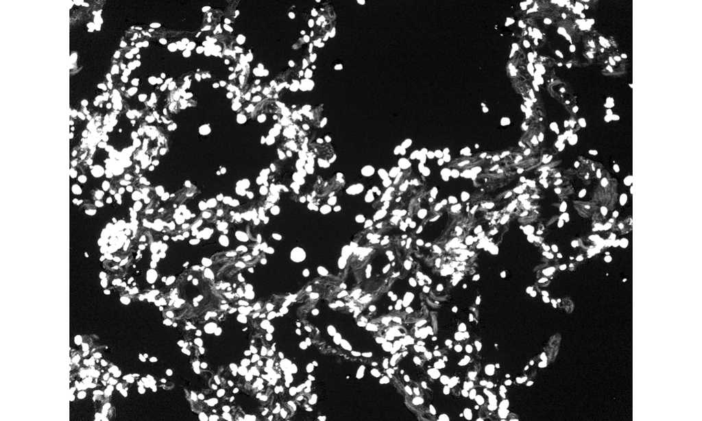

```r
dapi_channel = t(image_stack$"DAPI (DAPI)")
EBImage::display(dapi_channel, method = "raster")
```

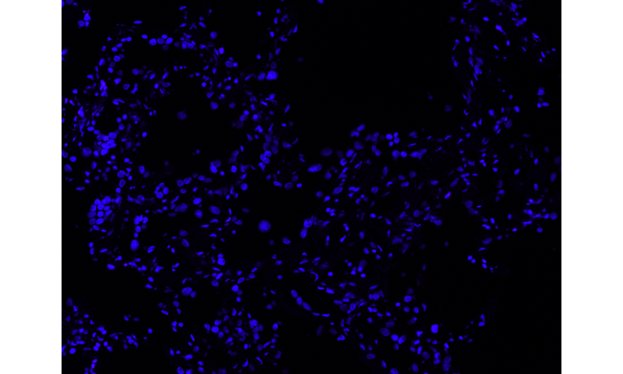

```r
# plot the image in a specified color
dapi = rgbImage(blue=.1*dapi_channel, red = .02 * dapi_channel)
display(dapi, method = "raster")
```

### Segmentation files

This data was collected on a Vectra 3 instrument and segmented using [inForm](https://www.akoyabio.com/phenoimager/software/inform-tissue-finder/) tissue analysis software from Akoya Biosciences. This is proprietary image analysis software that can perform cell and tissue segmentation and cell phenotyping. The segmentation below were performed by that software.

```r
# source phenoptr code for loading file and metadata, based on tiff::readTIFF.
source("https://raw.githubusercontent.com/akoyabio/phenoptr/main/R/read_maps.R")

segmentations = read_maps(segmentation)
names(segmentations)
```

```
## [1] "Nucleus"  "Membrane" "Tissue"
```

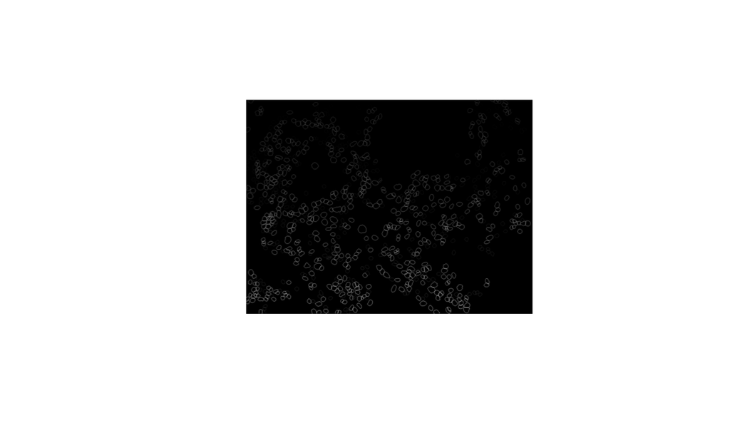

```r
nucleus = segmentations[['Membrane']]
plot(as.raster(nucleus, max = max(nucleus)))
```

Tissue segmentation

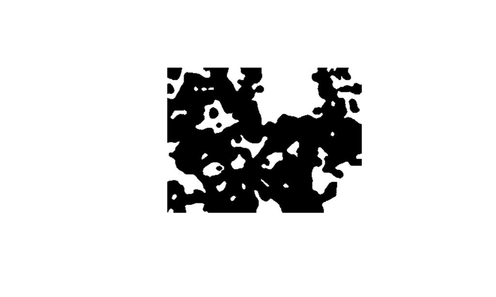

```r
tissue = segmentations[['Tissue']]

plot(as.raster(tissue, max = max(tissue)))
```

### Composite file

```r
# source phenoptr code for loading file and metadata, based on tiff::readTIFF.
source("https://raw.githubusercontent.com/akoyabio/phenoptr/main/R/read_composites.R")

composite = read_composites(composite_tif)
```

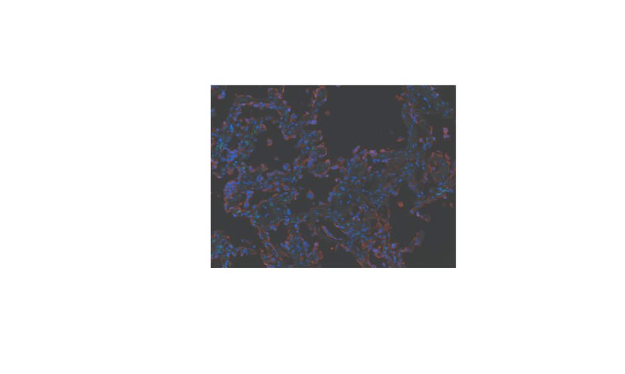

```r
composite = as.raster(composite[[1]])
plot(composite)
```

```r
knitr::opts_chunk$set(
  eval = FALSE)
```

## VectraPolarisData

The [VectraPolarisData](https://bioconductor.org/packages/release/data/experiment/html/VectraPolarisData.html) [ExperimentHub](http://bioconductor.org/packages/release/bioc/html/ExperimentHub.html) package provides two large multiplex immunofluorescence datasets collected using Akoya Biosciences Vectra 3 and Vectra Polaris platforms. Image preprocessing (cell segmentation and phenotyping) was performed using [inForm](https://www.akoyabio.com/phenoimager/software/inform-tissue-finder/) software. Data are provided as objects of class [SpatialExperiment](https://bioconductor.org/packages/release/bioc/html/SpatialExperiment.html).

```r
# load libraries
library(tidyverse)
```

### Install and load data

The data is publicly available on Bioconductor as the package `VectraPolarisData`. You can install the package from Bioconductor here:

```r
if (!requireNamespace("BiocManager", quietly = TRUE)) {
     install.packages("BiocManager")
}

BiocManager::install("VectraPolarisData")
```

## Ovarian cancer data

Load the high grade serous ovarian cancer data. This dataset has been segmented and phenotyped, and has one image per patient.

```r
library(VectraPolarisData)

# load spatial experiment object
oc <- HumanOvarianCancerVP()
```

Many of the variables are summary statistics of marker intensity values. More information on the different variables in this and the lung cancer dataset can be found in the [package vignette](https://bioconductor.org/packages/release/data/experiment/vignettes/VectraPolarisData/inst/doc/VectraPolarisData.html).

### Exploratory analysis

```r
dim(ovarian_df)

head(ovarian_df)

glimpse(ovarian_df)
```

Below we plot the cells for a single subject. In this dataset there is one image for each subject, and the image comes from a tumor microarray (TMA).

```r
id = sample(ovarian_df$sample_id, 1)

ovarian_df %>%
  filter(sample_id == id) %>%
  ggplot(aes(x, y)) +
  geom_point(aes(color = tissue_category), size = 0.1)
```

Now we plot the images (below) for multiple subjects. In this dataset, multiple TMA cores (each TMA core is frome a different subject) were placed on the same slide, and then that slide was imaged. X and Y locations in this data correspond to position on the slide for a given patient sample.

```r
ovarian_df %>%
  filter(sample_id < 10) %>%
  ggplot(aes(x, y)) +
  geom_point(aes(color = tissue_category), size = 0.1)
```

## Lung data

### Exploratory analysis

Below shows images from a single subject. Each image represents a different ROI from the same tissue slice from a single subject. There are 3-6 ROIs for each subject.

```r
id = sample(lung_df$patient_id, 1)

lung_df %>%
  filter(patient_id == id) %>%
  ggplot(aes(x, y)) +
  geom_point(aes(color = tissue_category), size = 0.1) +
  facet_wrap(~image_id)
```

## Additional Reading

Below are original citations for the two example datasets I will be working with in this tutorial.

- [Paper for ovarian cancer data](https://aacrjournals.org/mcr/article/19/12/1973/675069/The-Spatial-Context-of-Tumor-Infiltrating-Immune)
- [Paper for non-small cell lung carcinoma data](https://pubmed.ncbi.nlm.nih.gov/34048945/)
- [Vignette for VectraPolarisData](https://bioconductor.org/packages/release/data/experiment/vignettes/VectraPolarisData/inst/doc/VectraPolarisData.html)
- [textbook chapter, Wrobel and Vandekar](http://juliawrobel.com/Downloads/mIF_chapter.pdf)
- [Challenges and Opportunities in the Statistical Analysis of Multiplex Immunofluorescence Data](https://www.mdpi.com/2072-6694/13/12/3031)
- [Catching up with multiplexed tissue imaging](https://www.nature.com/articles/s41592-022-01428-z)
- [The emerging landscape of spatial profiling technologies](https://www.nature.com/articles/s41576-022-00515-3)